# Assignment (Lungani Style)

Lungani Myeni

2025-09-05

We will start by loading the data and plotting the path our animal follows.

```r
load("STA3043_Assignment1_2025.RData")
# Circular Library for the rvonmises function
library(circular)
```

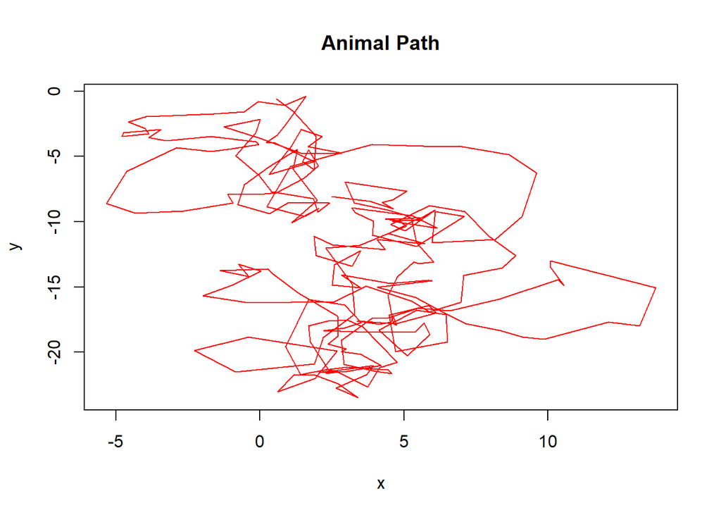

```r
#inputting Student Number
stu_num = "MYNLUN004"
number = which(names(Class.List)==stu_num)


x = Class.List[[number]][,2]

y = Class.List[[number]][,3]

# Plot of the animal's path
plot(x,y,col="red",type="l", main="Animal Path")
```

First, we shall obtain the likelihood. We see the velocity vectors $v_t$ are normally distributed with some unknown parameters. The likelihood expression for $n = 250$ and $a = \frac{1}{2}$ is therefore:

$$\begin{eqnarray*}
L(V,\theta) &\propto& \exp\left( -\frac{1}{2}\sum_{t=1}^{n}
\left( v_t - a\mathbf{M}v_{t-1}\right)^T\left( v_t - a\mathbf{M}v_{t-1}
\right) \right)\\
&\propto& \exp{\left( -\frac{1}{2}\sum_{t=1}^{n}v_t^Tv_t -
2av_{t}^T\mathbf{M}v_{t-1} +
a^2v_{t-1}^T{\mathbf{M}}^T{\mathbf{M}}v_{t-1}\right)}\\
\end{eqnarray*}$$

To simplify calculations, we note that

$${\mathbf{M}}^T{\mathbf{M}} =
\begin{pmatrix}
\cos\theta&-\sin\theta\\
\sin\theta&\cos\theta\\
\end{pmatrix}\begin{pmatrix}
\cos\theta&\sin\theta\\
-\sin\theta&\cos\theta\\
\end{pmatrix} = \begin{pmatrix}
1&0\\0&1\\
\end{pmatrix} = I_2$$

So the term $a^2v_{t-1}^TM^TMv_{t-1} = a^2v_{t-1}^Tv_{t-1}$. Both this term and the term $v_{t}^Tv_{t-1}$ are constants with respect to $\theta$, so they fall away in the proportionality expression of the likelihood. The only term needed to be expanded is then $v_{t-1}Mv_{t}$. We can note also that
$$v_{t} =
\boldsymbol{\mu}_{t} - \boldsymbol{\mu}_{t-1} =
\begin{pmatrix}{x_t-x_{t-1}}\\{y_{t}-y_{t-1}}\\\end{pmatrix} =
\begin{pmatrix}{\Delta{x_t}}\\{\Delta{y_t}}\\\end{pmatrix}$$

$$\begin{eqnarray*}
v_{t-1}\mathbf{M}v_{t}&=&
\begin{pmatrix}
\Delta{x_t}&\Delta{y_t}\\\end{pmatrix}
\begin{pmatrix}
\cos\theta&\sin\theta\\
-\sin\theta&\cos\theta\\
\end{pmatrix}\begin{pmatrix}{\Delta{x_{t-1}}}\\{\Delta{y_{t-1}}}\\\end{pmatrix}\\
& = & \begin{pmatrix}
\Delta{x_{t}}\\\Delta{y_{t}}\\
\end{pmatrix}\begin{pmatrix}{\Delta{x_{t-1}}\cos\theta+\Delta{y_{t-1}}\sin\theta}\\{\Delta{y_{t-1}}\cos\theta-
\Delta{x_{t-1}}\sin\theta}\\\end{pmatrix}\\
&=&\cos\theta\left(\Delta{x_{t}}\Delta{x_{t-1}} +
\Delta{y_t}\Delta{y_{t-1}}\right)+\\&&\sin\theta\left(\Delta{x_{t}}\Delta{y_{t-1}}
- \Delta{y_{t}\Delta{x_{t-1}}}\right)\\
\end{eqnarray*}$$

We can now recognise the posterior to have the form:

$$\pi(\theta|V)\propto \exp\left(
\frac{s_1\cos\theta+s_2\sin\theta}{2} \right) \qquad \text{for
$-\pi<\theta<\pi$}$$

where

$s_1 = \sum_{t=1}^{n}\left(\Delta{x_{t}}\Delta{x_{t-1}} + \Delta{y_t}\Delta{y_{t-1}}\right)$ and $s_2 = \sum_{t=1}^{n}\left(\Delta{x_{t}}\Delta{y_{t-1}} - \Delta{y_{t}\Delta{x_{t-1}}}\right)$

The constants s1 and s2 that we require are:

```r
lag_sum_1 = function(v1,v2){
  sumprod = 0
  for(i in 1:(length(v1)-2)){
    deltai = v1[i+2] - v1[i+1]
    deltai_1 = v2[i+1] - v2[i]
    sumprod = deltai*deltai_1 + sumprod
  }
  return(sumprod)
}

s1 = lag_sum_1(x,x) + lag_sum_1(y,y)
s2 = lag_sum_1(x,y) - lag_sum_1(y,x)
```

We shall first plot the posterior distribution and its logorithm.

[figure not shown]

Now we shall use the acceptance rejection algorithm to obtain samples from the posterior distribution defined above. We will be obtaining the samples of our $\theta$’s according to the sampling distribution and our given likelihood and data.

We have been given
$$h(\theta) \propto
e^{3\cos\theta}$$

Which we recognize to be the kernal of a von Mises distribution with $\mu = 0 \text{ and } \kappa = 3$ We first have our $\gamma(\theta)$ function that we want to obtain is :
$$\begin{eqnarray*}
\gamma(\theta) &=&
\frac{\pi(\theta)L(\theta,V)}{h(\theta)C}\\
&=&
\exp{\left(\frac{s1\cos(\theta)+s2\sin(\theta)}{2}-3\cos(\theta)\right)/\mathcal{C}}
\end{eqnarray*}$$

We will first obtain the constant $\mathcal{C}$ defined by:

$$\mathcal{C} =
\underset{\theta}{\max}\frac{\pi(\theta)
L(\theta,V)}{h(\theta)}$$

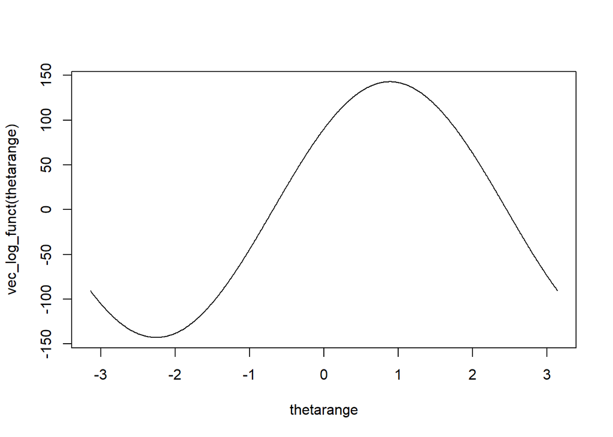

```r
# log of maximizing function for C
log_function = function(theta){
  t = (s1*cos(theta) + s2*sin(theta))/2-3*cos(theta)
  return(t)
}

# vectorization of the log function for plotting and maximizing
vec_log_funct = Vectorize(log_function,vectorize.args="theta")
plot(vec_log_funct(thetarange)~thetarange,type="l")
```

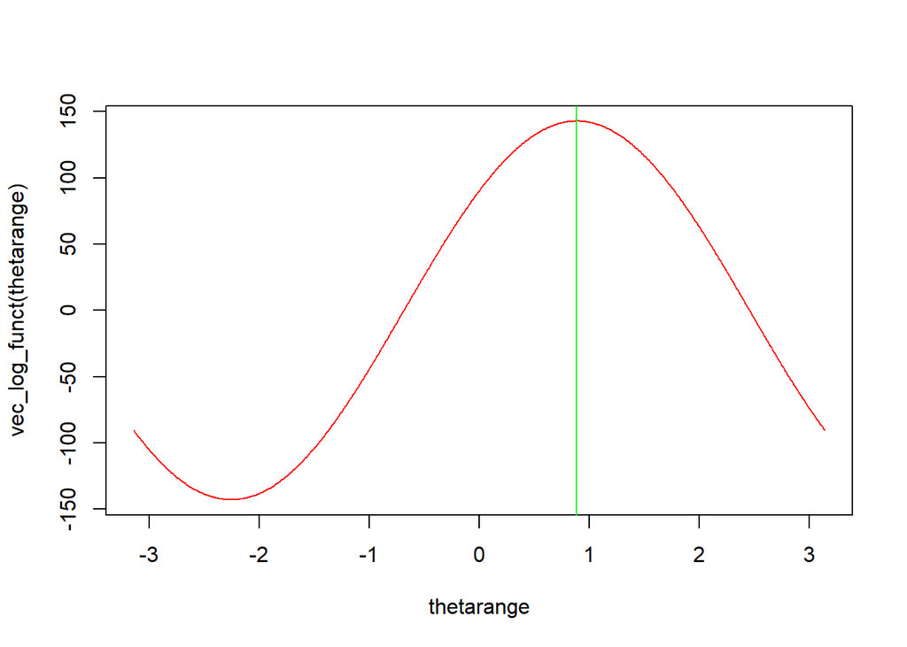

```r
# obtaining the maximum of our log function
maxtheta = optimise(vec_log_funct,interval=c(-pi,pi),maximum=T)
maxtheta = maxtheta$maximum


# calculating C by exponentiating log function
C = exp(log_function(maxtheta))


# plot of theta that maximizes objective function
plot(vec_log_funct(thetarange)~thetarange,type="l",col="red")
abline(v=maxtheta, col="green")
```

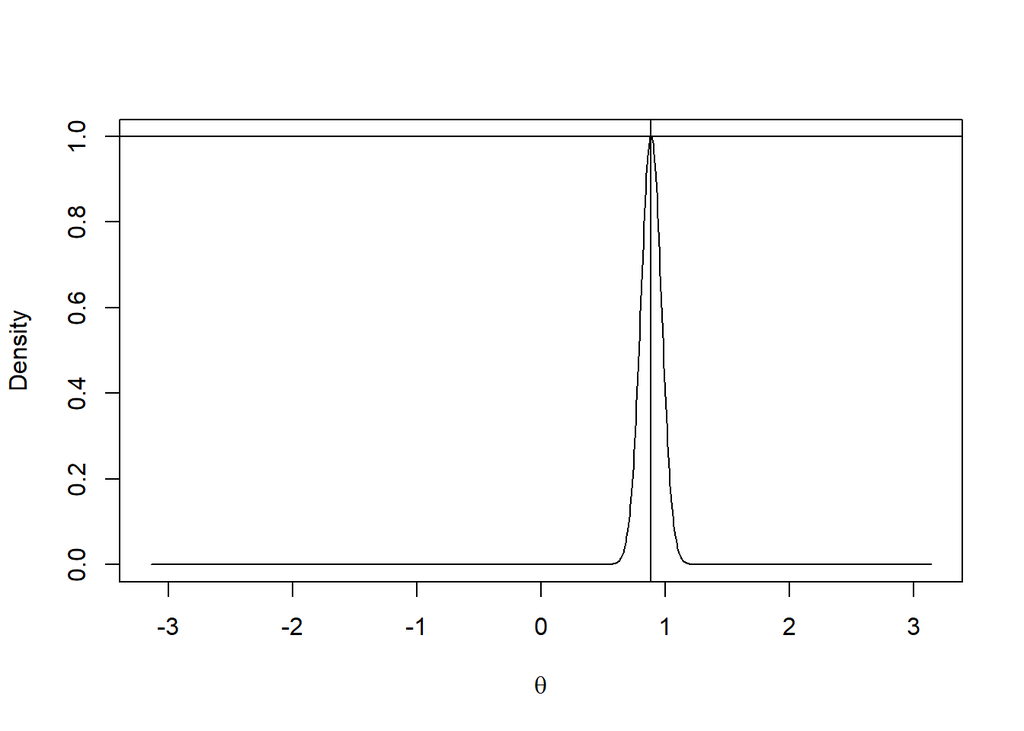

```r
# gamma function for obtaining potential theta samples
gamma_funct = function(theta){
  y = exp(1/2 * (s1*cos(theta) + s2*sin(theta)) - 3 * cos(theta))/(C)
  return(y)
}



# vectorized gamma function
gvec = Vectorize(gamma_funct,"theta")

# plot of gamma function
plot(gvec(seq(-pi,pi,0.01))~seq(-pi,pi,0.01),type="l",xlab=expression(theta),ylab="Density")
abline(v = c(maxtheta),h=gamma_funct(maxtheta))
```

Now we create the function to get the sampled $\theta$’s.

```r
ar = function(n){
  # stored vector of samples
  thet_vec = rep(NA,n)

  for(i in 1:n){
    while(is.na(thet_vec[i])){

      #generate random uniform and vonmises draws
      u = runif(1)
      thet = as.numeric(rvonmises(1,circular(0),3))

      # Displace pi's to [-pi,pi]
      if(thet>=pi){thet = thet-2*pi}
      g = gamma_funct(thet)
      if(u<=g){
        # accepted thetas
        thet_vec[i] = thet
      }
    }
  }
  return(thet_vec)
}


thetas = ar(5000)
summary(thetas)
```

```
##    Min. 1st Qu.  Median    Mean 3rd Qu.    Max.
##  0.5614  0.8116  0.8675  0.8680  0.9243  1.1283
```

We now plot the resulting posterior against the analytical expression.

```r
# plotting normalized posterior distribution


norm_post = function(x){
  # dividing by integrating constant for the analytical expression
  post_v(x)/integrate(post_v,lower=-pi,upper=pi)$value
}
?integrate
```

```
## starting httpd help server ... done
```

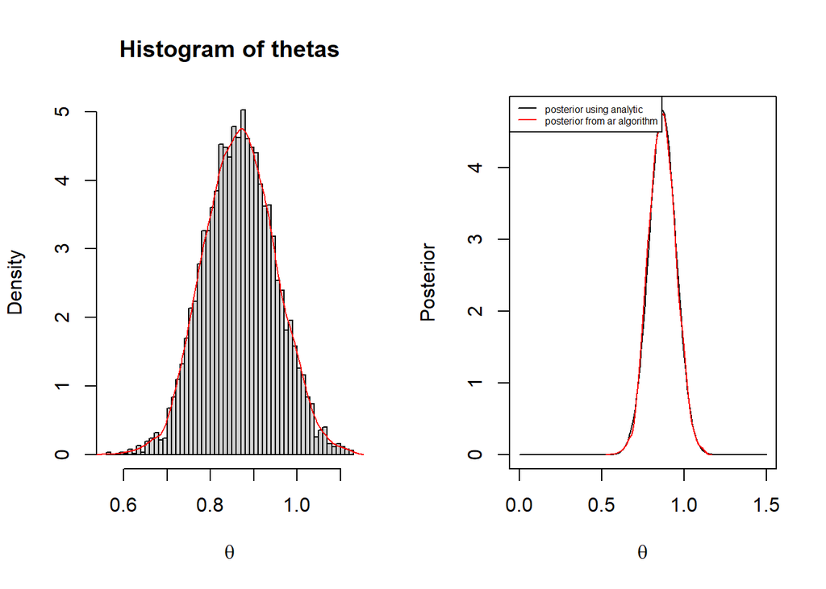

```r
# vectorized nomalized posterior distribution
norm_post_v = Vectorize(norm_post,"x")

# plotting histogram of sampled thetas
par(mfrow=c(1,2))
hist(thetas,freq=F,breaks=50, xlab=expression(theta), main="Histogram of thetas")
lines(density(thetas),col="red")

zer2 = seq(0,1.5,0.01)
plot(norm_post_v(zer2)~zer2,type="l", xlab=expression(theta),ylab="Posterior")
lines(density(thetas),col="red")
legend( x="topleft", col=c("black","red"),cex=0.5, lty=c(1,1),legend=c("posterior using analytic","posterior from ar algorithm"))
```